# CS5702 W1 Worksheet Notebook

Martin Shepperd

22/09/2021

# 0. Worksheet Topics

1. Seminar: Exploring R using R
2. Lab: Create, save and edit R Notebooks using RStudio
3. Lab: Some Basic R practice
4. Lab: Appendix - extra notes on YAML

**Pre-requisites**

1. You should have completed the Week 0 “Getting Ready” materials
2. You should have listened to the Week 1 Lecture “Modern Data Introduction”

This Worksheet is organised as an RMarkdown file. You can **read** it. You can **run** the embedded R and you can **add** your own R. I suggest you save it as another file so, if necessary, you can revert to the original.

Whenever you click **Preview** in the RStudio menu it will render this markdown into nicely formatted html which you can look at it in the Viewing Window in RStudio or via any web browser. You may find this easier to read, however, you must edit the .rmd file, i.e., the RMarkdown in the Edit Pane if you want to make any changes.

It comes in two parts:

1. material to support the Seminar
2. self-study material to check your understanding for the Lab

You are encouraged to explore and experiment. Change something and see what happens!

## 1. Seminar: Exploring R using R

### 1.1 Some Cute Examples using R

- [iris clustering](https://shiny.rstudio.com/gallery/kmeans-example.html)
- [football](https://www.datofutbol.cl/soccer-animate-r-package/)
- [buses in Minnesota](https://shiny.rstudio.com/gallery/bus-dashboard.html)

### 1.2 Demand for R programmers

How useful are R skills and tools? An [analysis](https://towardsdatascience.com/what-are-the-in-demand-skills-for-data-scientists-in-2020-a060b7f31b11) of 2681 data scientist job postings from 8 North American cities on January 25th, 2020 indicated the top 10 tools required by the employers are:

```
Python (62%)
SQL (40%)
R (39%)
Spark (21%)
Cloud (20%)
Amazon Web Services (20%)
Java (19%)
Tensorflow (16%)
Hadoop (15%)
SAS (13%)
```

The data was collected by analysing online job adverts for data scientists on the Indeed website in North America. Note that Tools is a categorical and multi-valued attribute of a job listing, i.e., one listing could have zero or more tool categories associated, thus the percentages do not sum to 100%. NB 14% of the sampled job listings are excluded (since it is stated that only 86% of adverts identified skills or tools).

**Exercise 1.1:** It’s important to look at the data critically, though we must accept nothing is certain or perfect! What questions or concerns might you have?

Since we’re thinking about data and data analysis, it would be helpful to visualise the data. Unfortunately, we don’t have access to the raw data so we will need to reproduce it. Therefore I have ‘scraped’ some of the data from their article and plugged this into R (see below). Don’t worry about the coding details for the present.

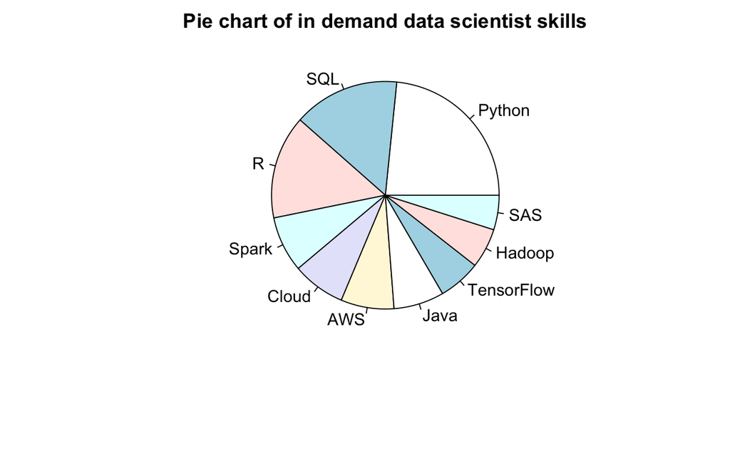

```r
# Reproduce the data from the January 2020 required skills analysis for Data Scientists

percent <- c(62,40,39,21,20,20,19,16,15,13)
skill <- c("Python","SQL","R","Spark","Cloud","AWS","Java","TensorFlow","Hadoop","SAS")
# Generate the pie chart
pie(percent, main="Pie chart of in demand data scientist skills", labels=skill)
```

**Exercise 1.2:** Using the `clockwise` parameter change the order of display. Type `?pie` for help if required.

**Exercise 1.3:** If you look at the help for the `pie()` function you will read “Pie charts are a very bad way of displaying information.” Why do you think this is so? [Prompt: what might be the impact of multi-valued data?]

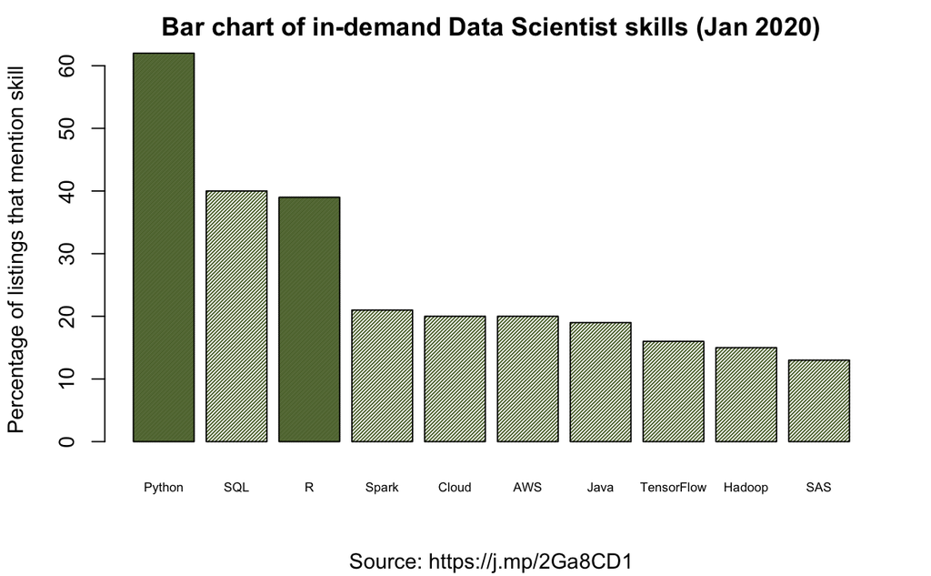

```r
# NB we have already reproduced the data: percent and skill come from the previous piechart chunk

# Generate a bar chart
barplot(percent,
main="Bar chart of in-demand Data Scientist skills (Jan 2020)",
sub = "Source: https://j.mp/2Ga8CD1",
ylab="Percentage of listings that mention skill",
names.arg=skill,
cex.names = 0.6,                                     # shrinks text size so fits on x-axis
col="darkolivegreen",                                # colour of the bars
density=c(100, 50, 100, 50, 50, 50, 50, 50, 50, 50)) # Shades Python and R in a darker colour
```

**Exercise 1.4:** Hopefully you consider this bar chart to be an improvement, but it’s not perfect. Can you think of any further improvements or clarifications? (Hint: some of the bars are quite hard to read off the exact proportion.) Remember that if the goal of Data Science is to *communicate* findings, then how we present information is of vital importance. For this reason we will return to this topic (Chapter 4) to dig deeper on data visualisation.

**Exercise 1.5:** The same [article](https://towardsdatascience.com/what-are-the-in-demand-skills-for-data-scientists-in-2020-a060b7f31b11) also lists the top 50 skills required e.g., machine learning, statistics, … Scrape (estimate the percentages for the top 10) and produce equivalent charts to those for these skills.

**Extension exercise 1.6:** The above two plots are performed using base R (which is perfectly adequate for simple charts). A powerful and flexible alternative is the {ggplot} package. How might you reproduce these charts using ggplot? NB This exercise is primarily intended for those who already have some knowledge of R or who consider themselves proficient programmers.

## 2. Lab: create, save and edit R Notebooks using R~Studio

This worksheet is written using RMarkdown and saved as an [R Notebook](https://blog.rstudio.com/2016/10/05/r-notebooks/).

It is an extremely convenient way to combine explanatory text written in a very simple markdown language and interactive R. We will use it for all non-trivial R code in this module, for seminars and you will need it for your coursework (CS5801) and exam (CS5802).

1. You need a YAML header (see this file for an example, or click here for more information).
2. You can enter plain text as-is.
3. You can use `#`, `##`, etc for different heading levels. Notice how RStudio automatically generates a nested navigation pane for you.
4. If you start a line with `1.` etc this generates an enumerated list (as per this example). There must be a space between the full stop and the text. If you just want bullets you can use `-` instead.
   - You can nest lists by indenting by 4 spaces.
5. You can insert a code chunk by clicking the green *Insert (Code Chunk)* button on the Edit Pane toolbar or by pressing *Cmd+Option+I*. Or you could, if you really want, type the three backticks followed by the language in braces, then the code and close the chunk with another three backticks.

There’s a very helpful guide on RMarkdown from RStudio [here](https://rmarkdown.rstudio.com/lesson-2.html).

Below is an example of an R code chunk which can be executed from within the R Notebook. You can do this by clicking the green triangle to the top right of the chunk area within the Notebook. If you wanted to run all the code up until, and including, this code chunk you can click the grey triangle with the green bar [^1].

```r
# This is an R code chunk
print("Hello cruel world")
```

[output not shown]

**Exercise 2.1:** Edit the R code to output “Goodbye cruel world” or some other message. Re-run the code chunk.

**Exercise 2.2:** Save the edited RMarkdown notebook When you save the notebook, an HTML file containing the code and output will also be saved (click the *Preview* button or press *Cmd+Shift+K* to preview the HTML file). The raw R markdown has a suffix .rmd and the rendered HTML will have a suffix nb.html.

Check you can see the html version. The preview shows you a rendered HTML copy of the contents of the editor. The output from the R code chunks is whatever was generated when it was last run in the RStudio. You can also view the file in any web browser.

```r
z <- 3
z <- z * 17
print(z)
```

[output not shown]

**Exercise 2.4:** Create a new RMarkdown file using the `File > New File > R Notebook` menu option. RStudio provides you with a basic template which you can modify as needed. Add a meaningful title and your name as an author in the YAML header. Render the file using the `Preview` option.

## 3. Lab: Some Basic R practice

### 3.1 A simple variable assignment example

In the previous task you may well have largely relied on the provided R code. Now we move onto learning about basic R syntax and some coding exercises for you to undertake.

Suppose I’m trying to calculate how much money I’m going to make from my *Modern Data* book. There are several different things I will need to store:

- `sales` how many copies I’ll sell `sales`
- `price` the price per copy
- `numberStudents` number of students in the class (assume I sell one copy per student)
- `recommend` the proportion of students so impressed that they recommend the book to friends and family
- `income` the income generated

Let’s turn this into R.

```r
# Compute sales income for Martin's book

price <- 10                                     # assume price is 10 UKP per book copy
numberStudents <- 100                           # number of students in the class
recommend <- 0.5                                # proportion of students who recommend the book

sales <- numberStudents * (1 + recommend)
income <- sales * price
paste("Martin will earn:", income)              # display a readable string with the paste function
```

```
[1] "Martin will earn: 1500"
```

```r
#print(outputMsg, quote = FALSE)                 # output the concatenated string without quotes
```

Although we could just output `income`, I have added some text to make the output of the code easier to interpret with the `paste()` function to combine a character string literal denoted by quotation marks and the calculated income.

**Exercise 3.1:** Change the number of students to 200 and the recommendation rate to 0.2. What’s my new estimated income?

**Exercise 3.2:** Update the sales income R code to handle tax. Assume that income is taxed at a flat rate of 20%. Modify the above R code to output gross income and net (after tax) income. Using RStudio you can edit this Week 1 Worksheet Notebook.

```r
# Your extended code needs to go here
```

HINT: I recommend you define a new numeric variable to store the tax rate and another for net income. For clarity you might want to rename `income` to make it obvious that it stores gross income.

**Bonus Exercise 3.3:** How would you answer the question: it’s possible to write a much shorter R program without any extra variables, so why bother?

It’s very *important* to get into the habit of writing easy to follow R code. For this reason I have added comments and tried to select meaningful variable names.